# Estudios de Informática, Multimedia y Telecomunicaciones

El caso de estudio sabemos que se pueden agrupar los datos en 3 especies de halcones (ratonero de cola roja, gavilán americano, gavilán de cooper) comprobaremos el comportamiento del algoritmo kmeans para 3 clústeres cogiendo de dos en dos las variables.

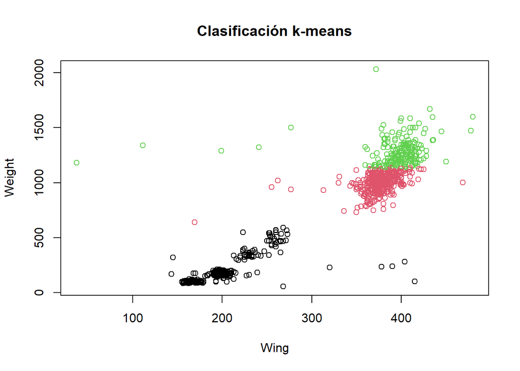

```r
Hawks3clusters <- kmeans(HawksTrait,3)

# Wing y Weight
plot(HawksTrait[c(1,2)], col=Hawks3clusters$cluster, main="Clasificación k-means")
```

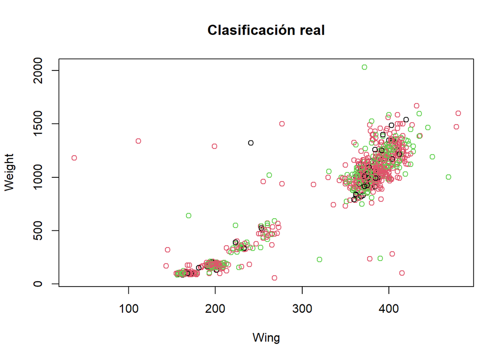

```r
plot(HawksTrait[c(1,2)], col=as.factor(Hawks$Species), main="Clasificación real")
```

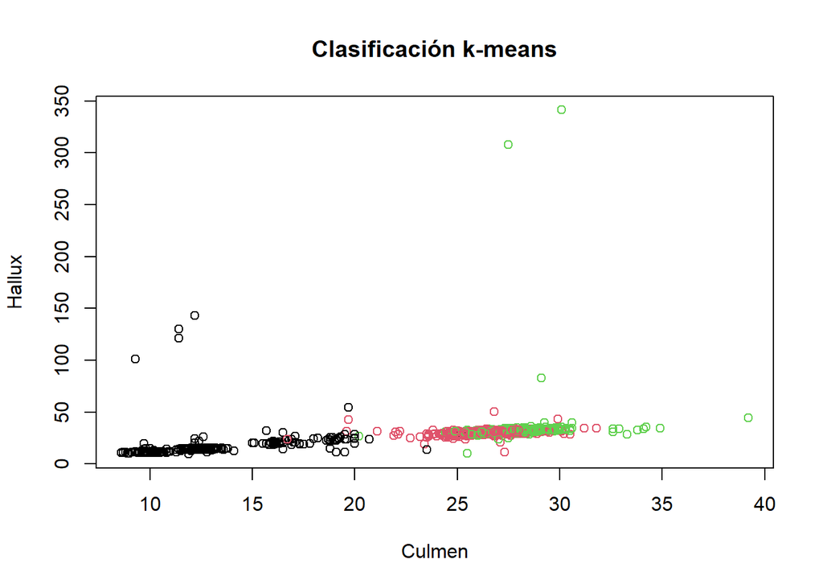

```r
# Culmen y Hallux
plot(HawksTrait[c(3,4)], col=Hawks3clusters$cluster, main="Clasificación k-means")
```

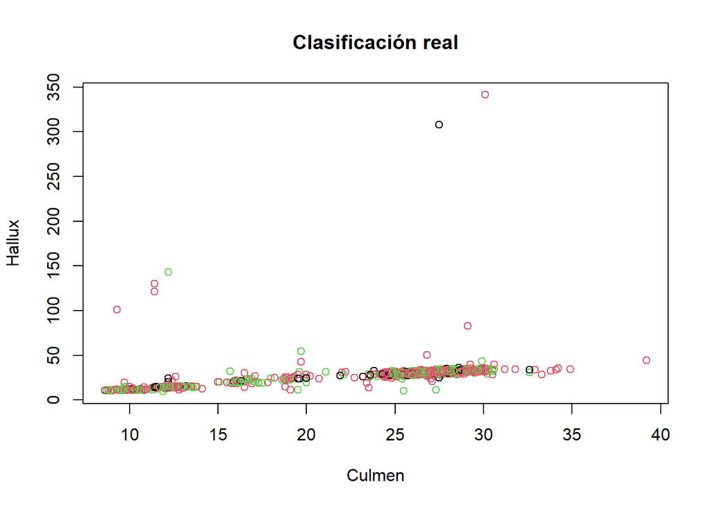

```r
plot(HawksTrait[c(3,4)], col=as.factor(Hawks$Species), main="Clasificación real")
```

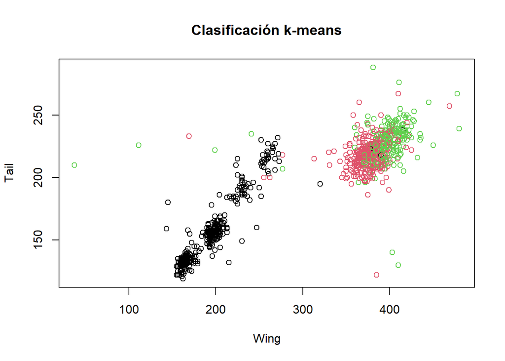

```r
# Wing y Tail
plot(HawksTrait[c(1,5)], col=Hawks3clusters$cluster, main="Clasificación k-means")
```

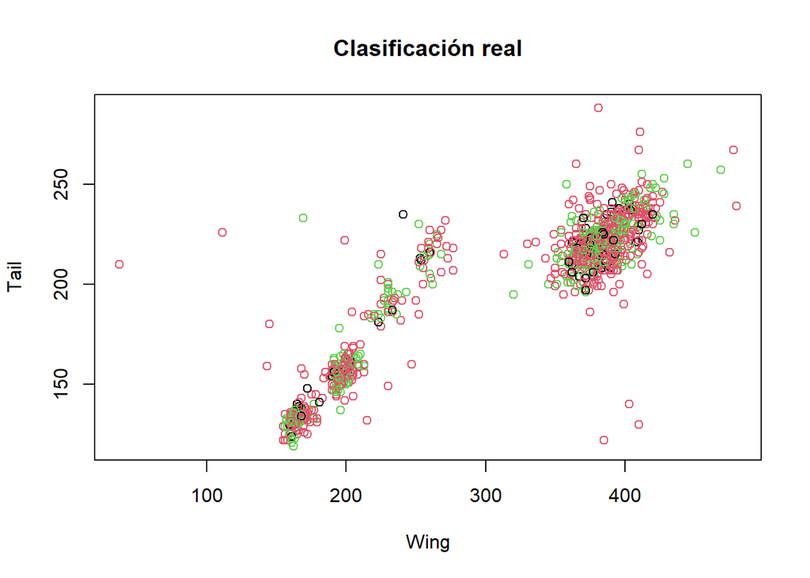

```r
plot(HawksTrait[c(1,5)], col=as.factor(Hawks$Species), main="Clasificación real")
```

Como podemos observar ninguna de las variables parece haber acertado en la clasificación en comparación con la clasificación real debido a que nos encontramos que la clasificación real es bastante dispersa. Por lo que no aparecen datos relevantes a la hora de clasificar el tipo de halcón de entre las especies de ratonero de cola roja, gavilán americano, gavilán de cooper

## 5.2 Ejercicio 2

Con el juego de datos proporcionado realiza un estudio similar al del ejemplo 2

### 5.2.1 Respuesta 2

Analizaremos ahora la muestra de datos de los halcones empleando los algoritmos de DBSCAN y OPTICS. Al igual que en el apartado anterior, aplicaremos el algoritmo a las variables de dos en dos.

Para las muestras de Wing y Weight aplicaremos una densidad mínima aceptada de 10.

```r
#Wing y Weight
resOptics12 <- optics(HawksTrait[c(1,2)], minPts = 10)
resOptics12
```

```
## OPTICS ordering/clustering for 891 objects.
## Parameters: minPts = 10, eps = 531.583483565846, eps_cl = NA, xi = NA
## Available fields: order, reachdist, coredist, predecessor, minPts, eps,
##                   eps_cl, xi
```

Mostramos el diagrama de alcanzabilidad para estas variables:

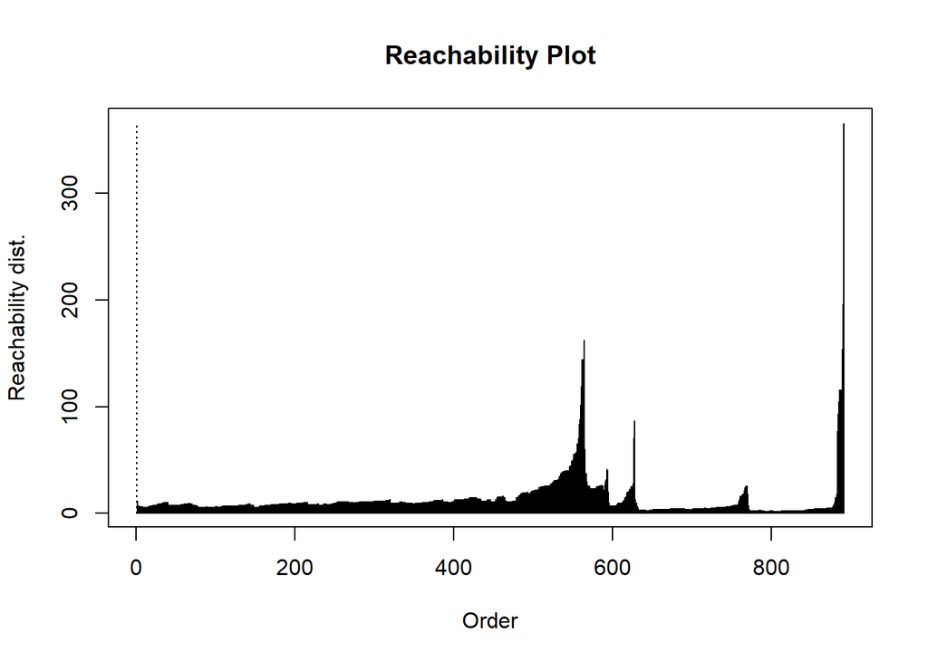

```r
plot(resOptics12)
```

En el diagrama podemos observar que a primera vista podríamos establecer la existencia de 5 clústeres debido a que se aprecian 5 valles en el diagrama.

A continuación mostramos el diagrama de alcanzabilidad, donde se observan las trazas de las distancias entre puntos cercanos.

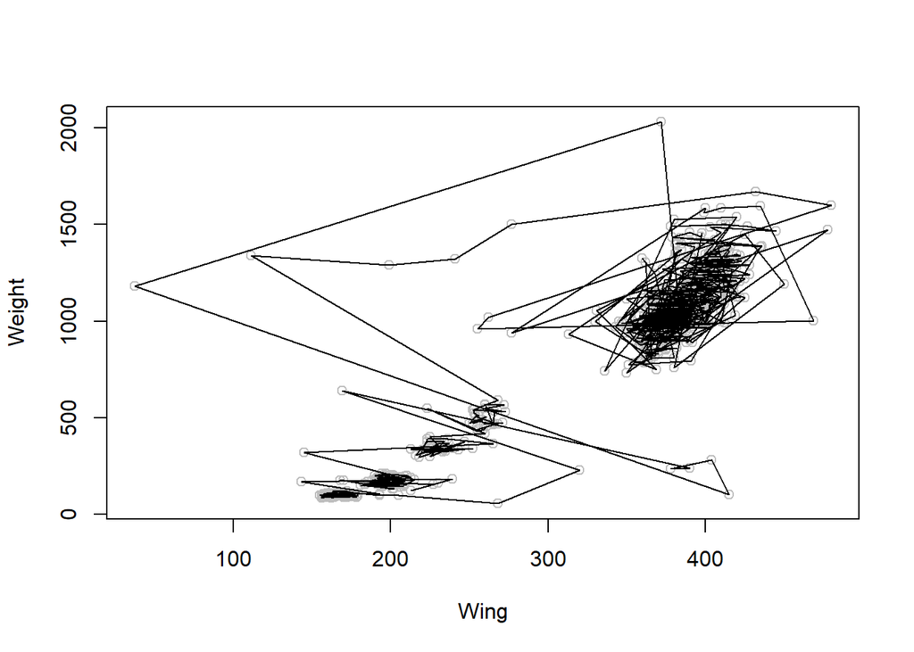

```r
plot(HawksTrait[c(1,2)],col="grey")
polygon(HawksTrait[resOptics12$order,])
```

Extraemos ahora las agrupaciones de la ordenación realizada por OPTICS como lo hubiera hecho el algoritmo DBSCAN estableciendo el radio del algoritmo en 50.

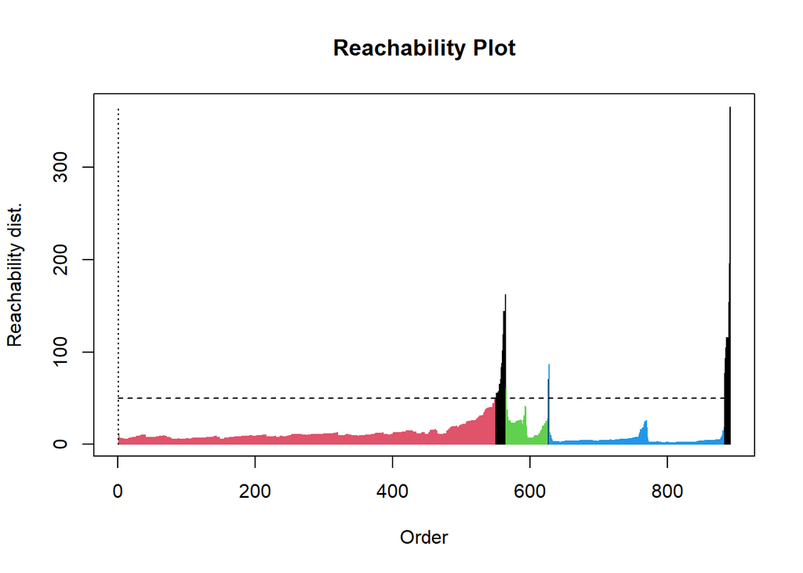

```r
resOptics12 <- extractDBSCAN(resOptics12, eps_cl = 50)
plot(resOptics12)
```

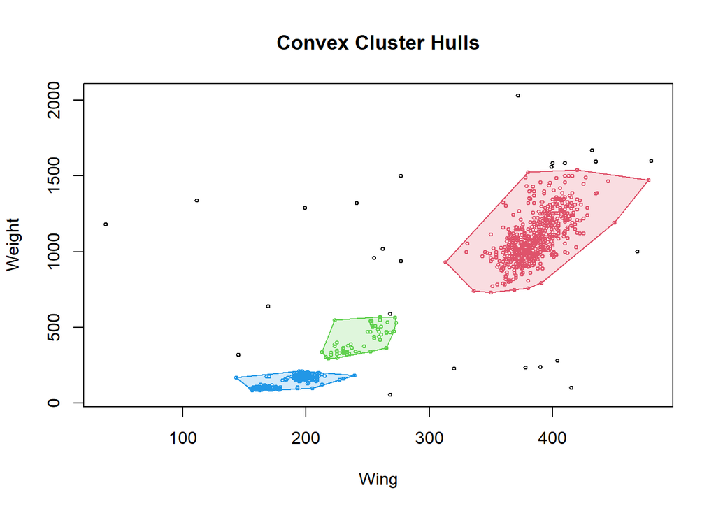

```r
hullplot(HawksTrait[c(1,2)], resOptics12)
```

Para este radio podemos observar que nos ha generado tres clústeres. hacemos una prueba ahora reduciendo el radio a 30 para ver si varía el número de clústeres ya que visualmente habíamos indicado la posibilidad de que se generasen 5 clústeres.

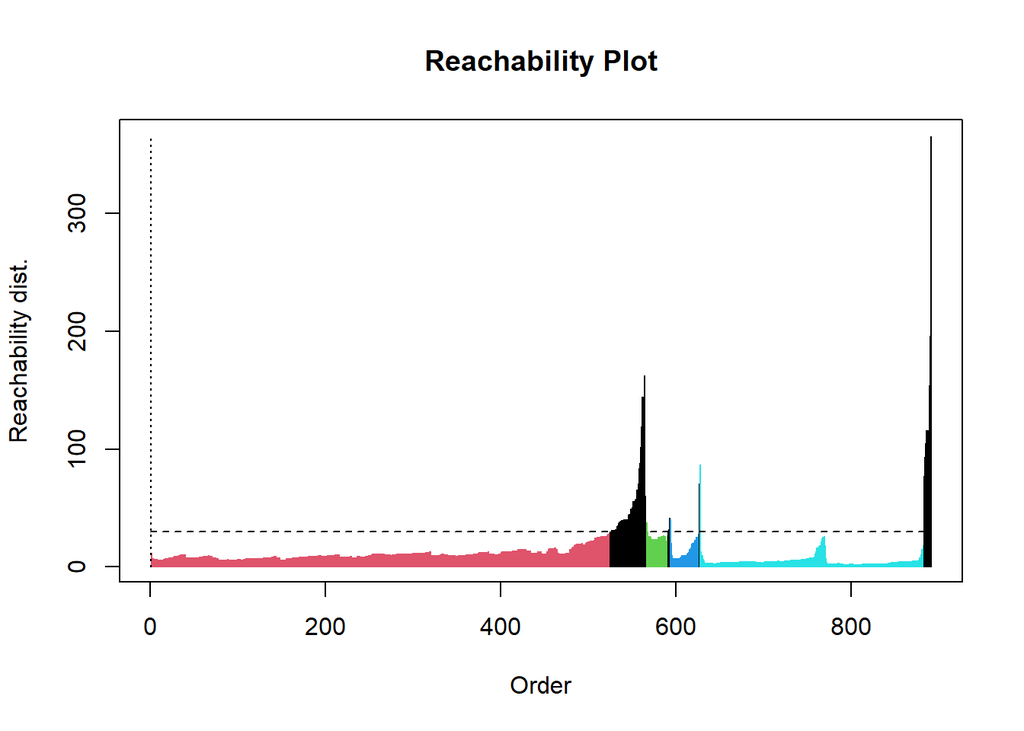

```r
resOptics12 <- extractDBSCAN(resOptics12, eps_cl = 30)
plot(resOptics12)
```

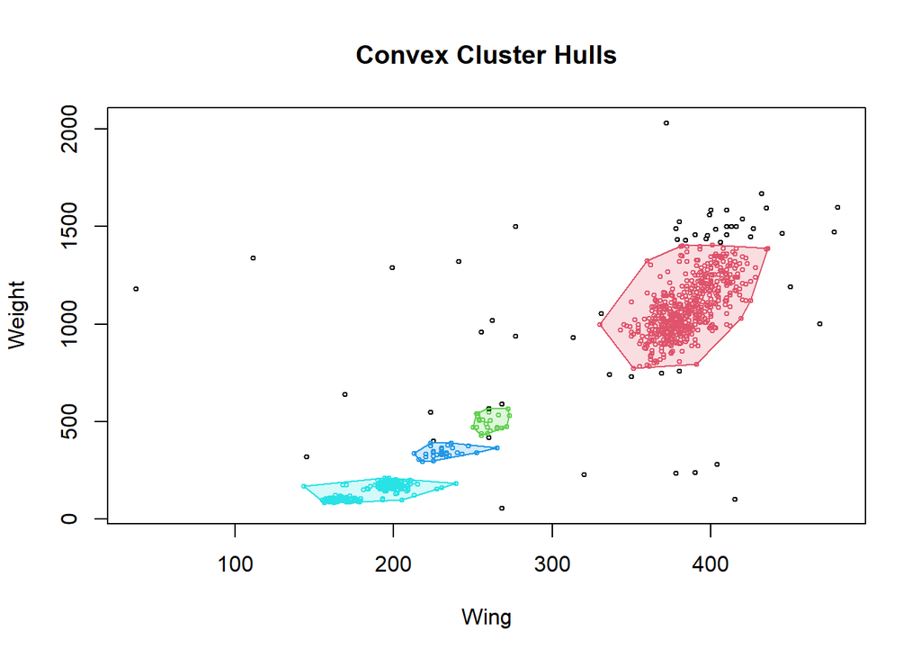

```r
hullplot(HawksTrait[c(1,2)], resOptics12)
```

Reduciendo el radio vemos que se ha generado un nuevo clúster pero se sigue sin alcanzar los 5 que definimos visualmente.

Realizamos una variante de la extracción DBSCAN en la que definimos el parámetro de la variación de la densidad en 0.2

```r
resOptics12 <- extractXi(resOptics12, xi = 0.2)
resOptics12
```

```
## OPTICS ordering/clustering for 891 objects.
## Parameters: minPts = 10, eps = 531.583483565846, eps_cl = NA, xi = 0.2
## The clustering contains 4 cluster(s) and 1 noise points.
##
## Available fields: order, reachdist, coredist, predecessor, minPts, eps,
##                   eps_cl, xi, cluster, clusters_xi
```

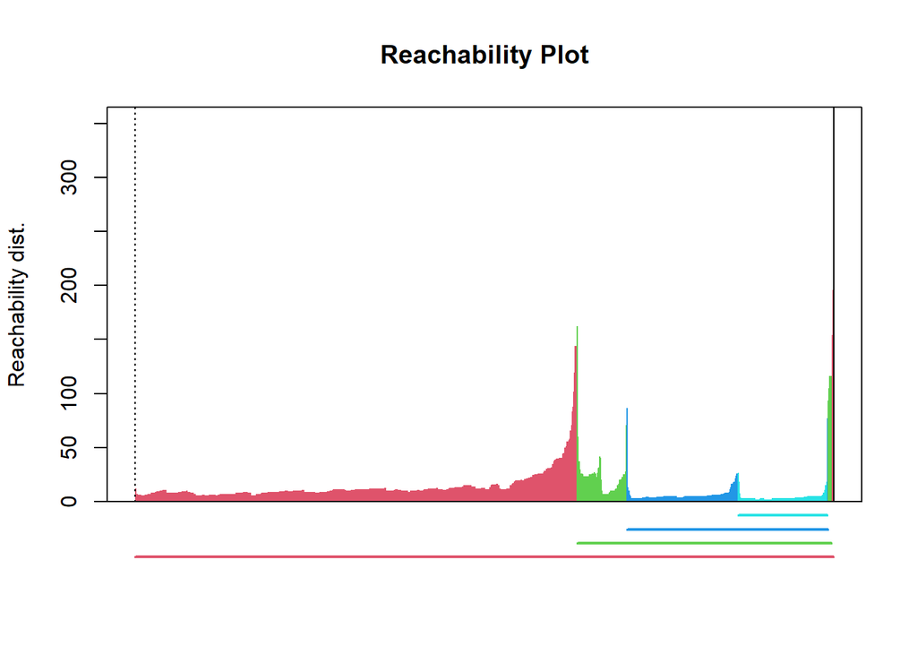

```r
plot(resOptics12)
```

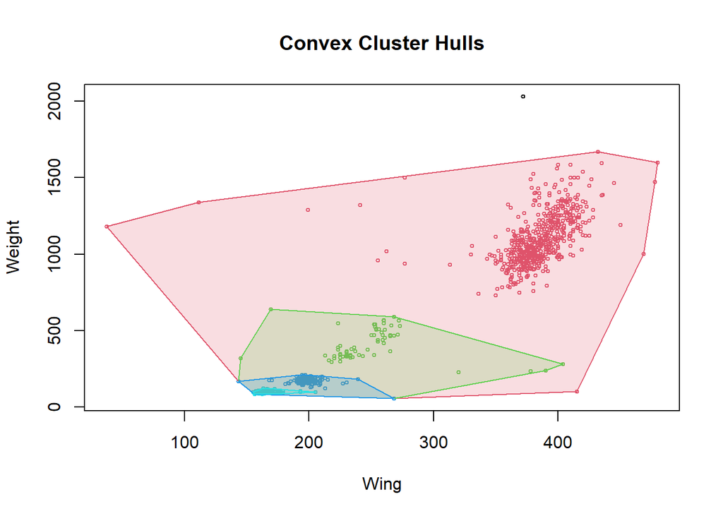

```r
hullplot(HawksTrait[c(1,2)], resOptics12)
```

Realizamos el estudio ahora para las variables de Culmen y Hallux

```r
#Culmen y Hallux
resOptics34 <- optics(HawksTrait[c(3,4)], minPts = 10)
resOptics34
```

```
## OPTICS ordering/clustering for 891 objects.
## Parameters: minPts = 10, eps = 298.200067069074, eps_cl = NA, xi = NA
## Available fields: order, reachdist, coredist, predecessor, minPts, eps,
##                   eps_cl, xi
```

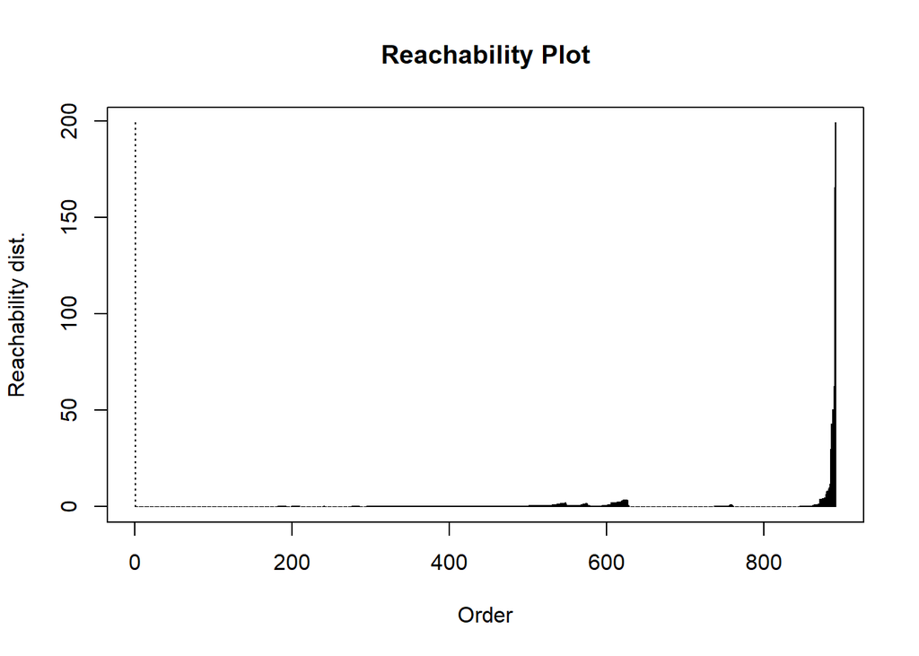

```r
plot(resOptics34)
```

En este caso observamos que se dificulta el definir el número de clústeres generados visualmente. Podemos observar que el radio en este caso va a ser bastante bajo para poder conformar bien los clústeres. Definimos el radio en 2

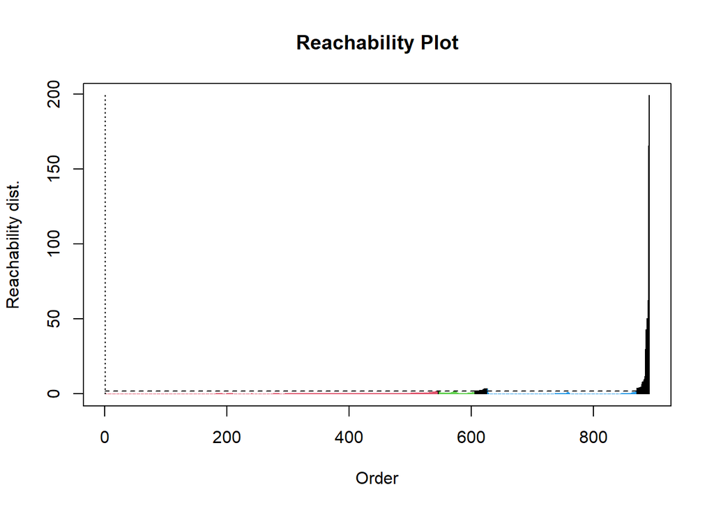

```r
resOptics34 <- extractDBSCAN(resOptics34, eps_cl = 2)
plot(resOptics34)
```

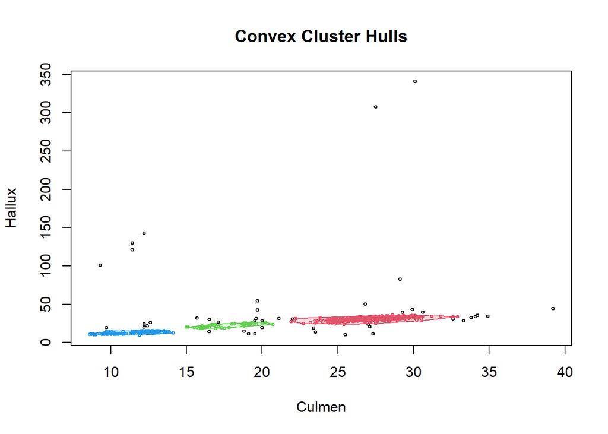

```r
hullplot(HawksTrait[c(3,4)], resOptics34)
```

Se puede observar que en este caso el algoritmo ha generado 3 clústeres.

Observamos ahora el clustering jerárquico de estas variables.

```r
resOptics34 <- extractXi(resOptics34, xi = 0.15)
resOptics34
```

```
## OPTICS ordering/clustering for 891 objects.
## Parameters: minPts = 10, eps = 298.200067069074, eps_cl = NA, xi = 0.15
## The clustering contains 5 cluster(s) and 1 noise points.
##
## Available fields: order, reachdist, coredist, predecessor, minPts, eps,
##                   eps_cl, xi, cluster, clusters_xi
```

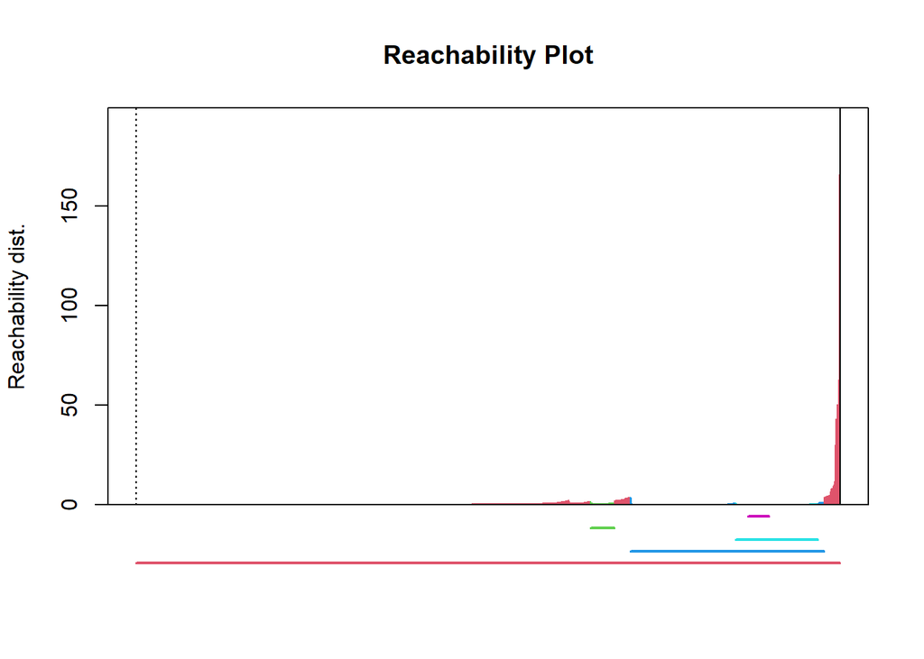

```r
plot(resOptics34)
```

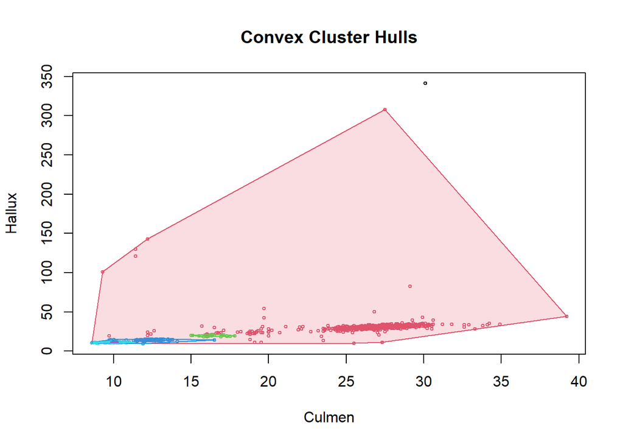

```r
hullplot(HawksTrait[c(3,4)], resOptics34)
```

Por último realizamos el estudio para las variables de Wing y Tail.

```r
#Wing y Tail
resOptics15 <- optics(HawksTrait[c(1,5)], minPts = 10)
resOptics15
```

```
## OPTICS ordering/clustering for 891 objects.
## Parameters: minPts = 10, eps = 143.373079760463, eps_cl = NA, xi = NA
## Available fields: order, reachdist, coredist, predecessor, minPts, eps,
##                   eps_cl, xi
```

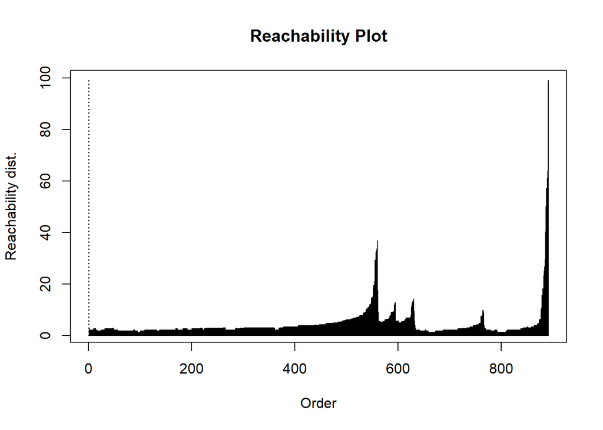

```r
plot(resOptics15)
```

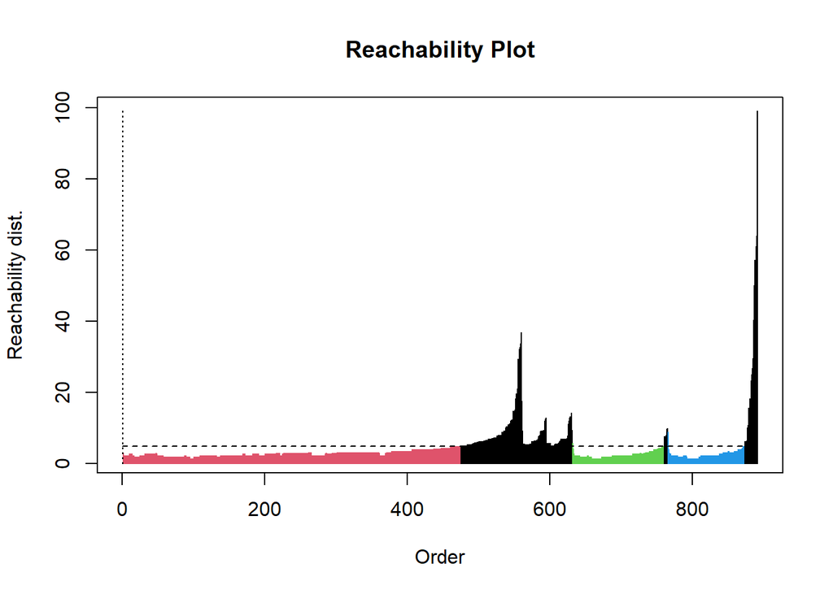

```r
resOptics15 <- extractDBSCAN(resOptics15, eps_cl = 5)
plot(resOptics15)
```

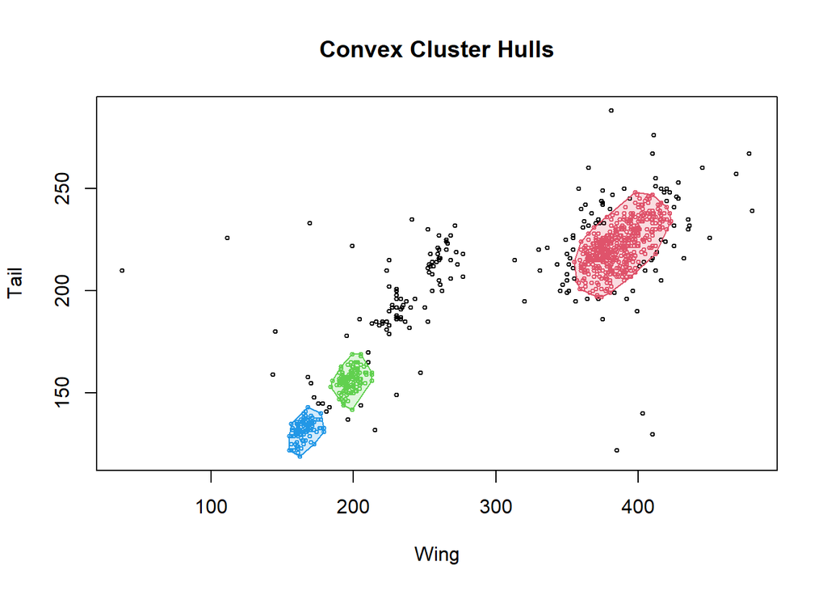

```r
hullplot(HawksTrait[c(1,5)], resOptics15)
```

Por último observamos el clustering jerárquico de estas variables con una variación de la densidad de 0.15.

```r
resOptics15 <- extractXi(resOptics15, xi = 0.15)
resOptics15
```

```
## OPTICS ordering/clustering for 891 objects.
## Parameters: minPts = 10, eps = 143.373079760463, eps_cl = NA, xi = 0.15
## The clustering contains 6 cluster(s) and 1 noise points.
##
## Available fields: order, reachdist, coredist, predecessor, minPts, eps,
##                   eps_cl, xi, cluster, clusters_xi
```

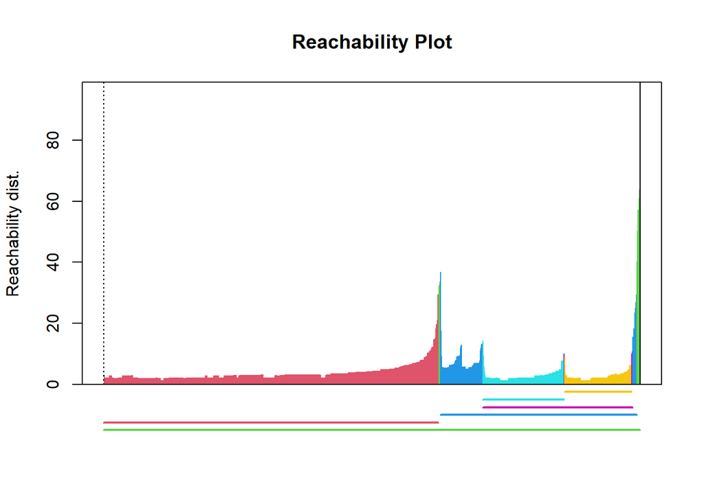

```r
plot(resOptics15)
```

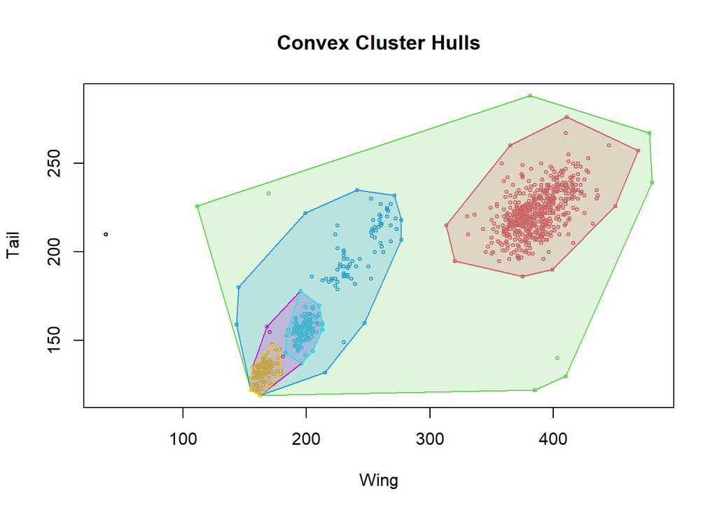

```r
hullplot(HawksTrait[c(1,5)], resOptics15)
```

## 5.3 Ejercicio 3

Realiza una comparativa de los métodos *k-means* y *DBSCAN*

### 5.3.1 Respuesta 3

Analizando los resultados podemos ver que el método de k-means no nos ha servido para realizar la clasificación correcta del tipo de halcón con los datos seleccionados, lo que nos indica que no son datos relevantes para la clasificación.

De la aplicación de k-means podemos observar que ha clasificado todos los valores en un clúster, incluso valores extremos en contraparte del método de DBSCAN el cual no ha identificado entro de ningún clúster dichos valores extremos, lo que nos muestra un clúster de mayor calidad.

La principal ventaja que encontramos a la hora de aplica el método de k-means es su sencillez y rapidez, pero posee un inconveniente que consiste en que debemos de predefinir el número de clústeres a obtener lo cual nos lleva a realizar un estudio previo para asegurarnos de elegir el valor correcto.

En contra parte nos encontramos con el método DBSCAN el cual posee las ventajas de identificar clústeres de cualquier forma geométrica ya que sólo necesita que existan zonas de alta y baja densidad para poder identificar los diferentes clústeres, lo cual indica la segunda ventaja que es que no se han de predefinir el número de clústeres a obtener. Como inconveniente tiene que debemos definir el máximo radio de vecindad y el mínimo número de puntos dentro de la vecindad.

# 6 Criterios de evaluación

## 6.1 Ejercicio 1

- 10%. Se explican los campos de la base de datos
- 25%. Se aplica el algoritmo de *k-means* de forma correcta.
- 25%. Se prueban con diferentes valores de k.
- 10%. Se obtiene una medida de lo bueno que es el agrupamiento.
- 20%. Se describen e interpretan los diferentes clusters obtenidos.
- 10%. Se presenta el código y es fácilmente reproducible.

## 6.2 Ejercicio 2

- 20%. Se aplican lo algoritmos *DBSCAN* y *OPTICS* de forma correcta.
- 25%. Se prueban con diferentes valores de eps.
- 25%. Se obtiene una medida de lo bueno que es el agrupamiento.
- 20%. Se describen e interpretan los diferentes clusters obtenidos.
- 10%. Se presenta el código y es fácilmente reproducible.

## 6.3 Ejercicio 3

- 35%. Se comparan los resultados obtenidos en *k-means* y *DBSCAN*.
- 35%. Se mencionan pros y contras de ambos algoritmos
- 30%. Se exponen la conclusiones del trabajo